# act_report

## Report: act_report

- Create a **250-word-minimum written report** called "act_report.pdf" or "act_report.html" that communicates the insights and displays the visualization(s) produced from your wrangled data. This is to be framed as an external document, like a blog post or magazine article, for example.

Three insights were generated from the WeRateDogs dataset analysis. They are; the most common dog names as appeared in the data, the most common source of tweet and the most liked and retweeted tweet.

## Most Popular Dog Name

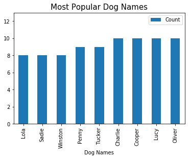

## Most common tweet source

when the source of tweets were analysed, we identified 4 tweet sources being, tweetdeck, Twitter web, Vine and Iphone. 93.7% of all the tweets came from Twitter for iphone which makes it undoubtedly the most common tweet source. this is visualused in a pie chat as attached below;

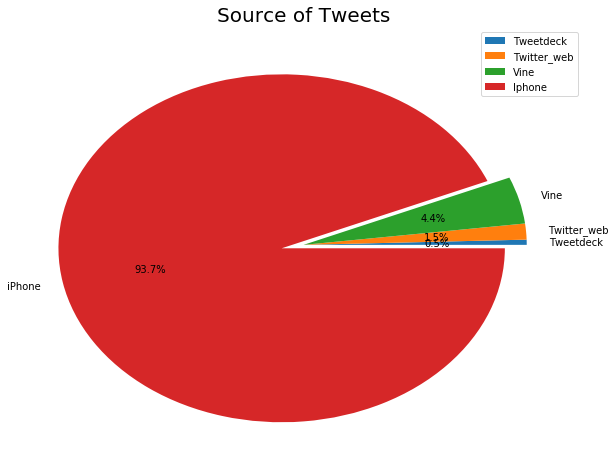

## Most favorited and retweeted tweet

The most favorited and retweeted tweet is the tweet with tweet_id 744234799360020481. the tweet in itself reads; 'Here's a doggo realizing you can stand in a pool.'